# Project_SVHN_DigitRecog_Submission_02

### Importing Libraries

```python
import warnings
import tensorflow as tf
```

```python
#Viewing Tenserflow version
tf.__version__
```

```
'2.1.0'
```

```python
import matplotlib.pyplot as plt

from sklearn.model_selection import train_test_split
from tensorflow.keras.datasets import fashion_mnist
from tensorflow.keras.models import Sequential
from tensorflow.keras.utils import to_categorical

from tensorflow.keras.models import Sequential
from tensorflow.keras.layers import Activation, Dense
from tensorflow.keras import optimizers
from tensorflow.keras.layers import BatchNormalization, Dropout
```

```python
import gdown

%matplotlib inline

import pandas as pd
import numpy as np
import matplotlib.pyplot as plt
import seaborn as sns
```

### Downloading Data

#### Downloading data from google drive

```python
sharedUrl='https://drive.google.com/file/d/1L2-WXzguhUsCArrFUc8EEkXcj33pahoS/view'
dwd_url='https://drive.google.com/uc?export=download&id=' + sharedUrl.split('/')[-2]

id = sharedUrl.split("/")[-2]

output='SVHN_single_grey1.h5'
gdown.download(dwd_url,output,quiet=False)
```

[output not shown]

[output cut: 856 more lines]

[output not shown]

```
'SVHN_single_grey1.h5'
```

```python
#df = pd.read_hdf('SVHN_single_grey1.h5')
#print(df)
```

```python
import h5py

data=h5py.File('SVHN_single_grey1.h5','r')
```

```python
data.keys()
```

```
<KeysViewHDF5 ['X_test', 'X_train', 'X_val', 'y_test', 'y_train', 'y_val']>
```

- H5PY file has 3 sets of data for train, test and validation

### Extracting data from H5PY file

- Saving data from H5PY file desiered variables

```python
X_train=data['X_train'][:]
X_test=data['X_test'][:]
X_val=data['X_val'][:]
y_train=data['y_train'][:]
y_test=data['y_test'][:]
y_val=data['y_val'][:]
```

```python
'''
X_train=data.get('X_train')
X_test=data.get('X_test')
X_val=data.get('X_val')
y_train=data.get('y_train')
y_test=data.get('y_test')
y_val=data.get('y_val')
'''
```

```
"\nX_train=data.get('X_train')\nX_test=data.get('X_test')\nX_val=data.get('X_val')\ny_train=data.get('y_train')\ny_test=data.get('y_test')\ny_val=data.get('y_val')\n"
```

### Exploring data

- Data types of downloaded data sets

```python
print("Training data X-- Shape :", X_train.shape,"and Data Type : ", X_train.dtype)
print("Testing data X-- Shape :", X_test.shape,"and Data Type : ", X_test.dtype)
print("Validation data X-- Shape :", X_val.shape,"and Data Type : ", X_val.dtype)
print("Training data y-- Shape :", y_train.shape,"and Data Type : ", y_train.dtype)
print("Testing data y-- Shape :", y_test.shape,"and Data Type : ", y_test.dtype)
print("Validation data y-- Shape :", y_val.shape,"and Data Type : ", y_val.dtype)
```

```
Training data X-- Shape : (42000, 32, 32) and Data Type :  float32
Testing data X-- Shape : (18000, 32, 32) and Data Type :  float32
Validation data X-- Shape : (60000, 32, 32) and Data Type :  float32
Training data y-- Shape : (42000,) and Data Type :  uint8
Testing data y-- Shape : (18000,) and Data Type :  uint8
Validation data y-- Shape : (60000,) and Data Type :  uint8
```

- All data set contains images of size 32 * 32 and their lables
- Train Data:
  - Total Images: 42000
  - Image size: 32 X 32
  - Image/Independent Data type saved as float
  - Dependent or expected output saved as uint8
- Test Data:
  - Total Images: 18000
  - Image size: 32 X 32
  - Data type saved as float
  - Image/Independent Data type saved as float
  - Dependent or expected output saved as uint8
- Validation Data:
  - Total Images: 60000
  - Image size: 32 X 32
  - Data type saved as float
  - Image/Independent Data type saved as float
  - Dependent or expected output saved as uint8

Show first number in the train data set with expected label

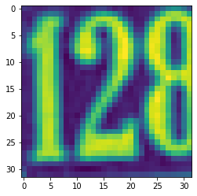

```
Label:  2
```

```python
plt.imshow(X_train[0])    # show first number in the train dataset
plt.show()
print('Label: ', y_train[0])
```

- on screen we can see there are 3 clear identifiable numbers 1,2,8 but it is tagged to digit 2 only
- current image is taking the output as 2 which is the center value

Randomly taking a value from middle of data set - 1050

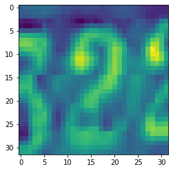

```
Label:  2
```

```python
plt.imshow(X_train[1050])
plt.show()
print('Label: ', y_train[1050])
```

- we can still notice the similar pattern as it takes the expected value of middle digit

First Value in Test data sets

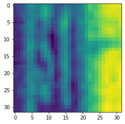

```
Label:  1
```

```python
plt.imshow(X_test[0])    # show first number in the test dataset
plt.show()
print('Label: ', y_test[0])
```

[figure not shown]

```
Label:  4
```

```python
plt.imshow(X_test[200])
plt.show()
print('Label: ', y_test[200])
```

First value in Validation data set

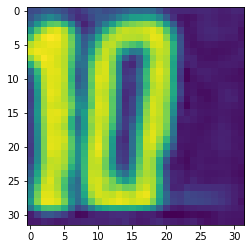

```
Label:  0
```

```python
plt.imshow(X_val[0])    # show first number in the val dataset
plt.show()
print('Label: ', y_val[0])
```

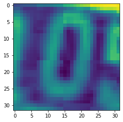

```
Label:  0
```

```python
plt.imshow(X_val[900])
plt.show()
print('Label: ', y_val[900])
```

- We can observe the variation in digits in Validation and Test data sets are similar to Train

```
Label:  2
Label:  6
Label:  7
Label:  4
Label:  4
Label:  0
Label:  3
Label:  0
Label:  7
Label:  3
```

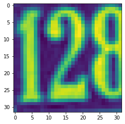

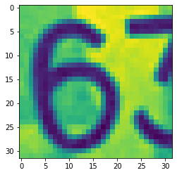

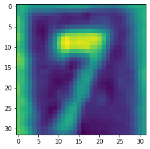

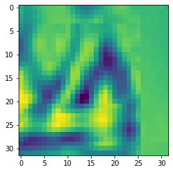

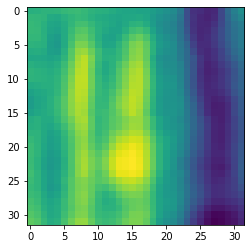

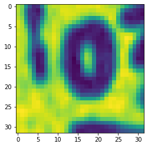

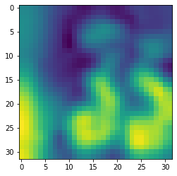

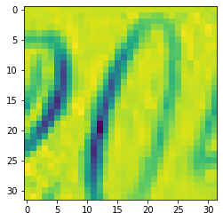

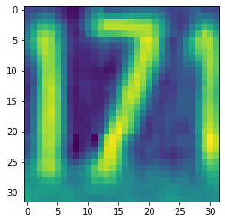

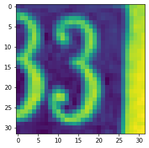

```python
#Visualize the data, Plot first 10 images in the triaining set and their labels.
import matplotlib.pyplot as plt
%matplotlib inline
for i in range(10):
    image = X_train[i]
    plt.figure(i)
    plt.imshow(image)
    print('Label: ', y_train[i])
```

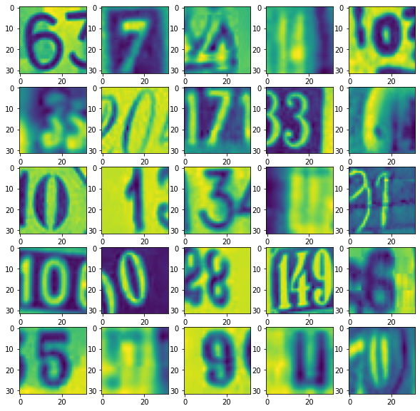

```
Label:  [6 7 4 4 0 3 0 7 3 1 0 1 3 1 1 0 0 8 4 6 5 7 9 1 0]
```

```python
#view 10 train images
#check for orientation and alignments

fig=plt.figure(figsize=(10,10))

for i in range(1,26):
  img=X_train[i]
  fig.add_subplot(5,5,i)
  plt.imshow(img)

plt.show()
print('Label: ', y_train[1:26])
```

- We can notice there are multiple image with more than one clear images of digit or just one or a blur image of all
- Orientation is as well not straight for all
- Digits are of different font and sizes as well
- Will try to look the values in grayscale

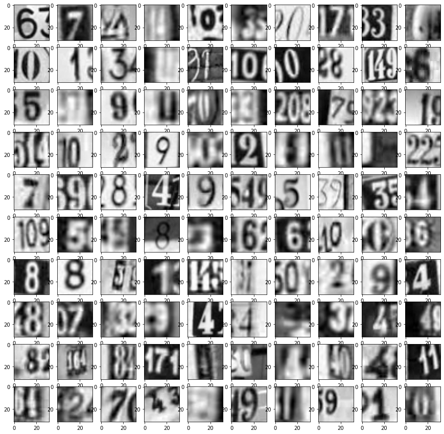

```
Label:  [6 7 4 4 0 3 0 7 3 1 0 1 3 1 1 0 0 8 4 6 5 7 9 1 0 3 0 7 2 1 1 0 2 9 0 2 5
 1 3 2 7 9 8 4 9 4 5 9 3 4 0 5 5 8 3 6 6 0 0 6 8 8 3 1 4 7 0 2 9 4 8 7 3 9
 4 4 3 3 4 4 8 6 8 7 4 0 4 4 4 1 4 2 7 4 2 9 1 9 1 0]
```

```python
#numbers are tilted and not in center
#multiple numbers with similar match
#consider 149 in image or 33 or 11
#check for more orientation and alignments, check in gray scale

fig=plt.figure(figsize=(15,15))

for i in range(1,101):
  img=X_train[i]
  fig.add_subplot(10,10,i)
  plt.imshow(img,cmap='gray')

plt.show()


print('Label: ', y_train[1:101])
```

### Reshape and normalize the train and test features

### Data Pre Processing

```python
#Re importing to set the data from this point -- comment the section later

X_train=data['X_train'][:]
X_test=data['X_test'][:]
X_val=data['X_val'][:]
y_train=data['y_train'][:]
y_test=data['y_test'][:]
y_val=data['y_val'][:]
```

```python
X_train.shape
```

```
(42000, 32, 32)
```

- Current shape of data is - 42,000 images with 32X32 image size
- We have to reshape the data before model creation or we can do it while model creation as well with model.add(tf.keras.layers.Reshape((1024,),input_shape=(32,32,)))

#### Reshape train and test sets into compatible shapes

- Sequential model in tensorflow.keras expects data to be in the format (n_e, n_h, n_w, n_c) n_e= number of examples, n_h = height, n_w = width, n_c = number of channels
- labels will be converted to categorical variables

```python
X_train = X_train.reshape((X_train.shape[0], 32,32,1))
X_test = X_test.reshape((X_test.shape[0], 32,32,1))
X_val = X_val.reshape((X_val.shape[0],32,32,1))
```

#### Normalizing data

- dividing the RGB codes with 255 (which is the maximum RGB code minus the minimum RGB code)
- normalize X_train, X_test & X_val
- making sure values are float so that we can get decimal points after division

```python
X_train = X_train.astype('float32')
X_test = X_test.astype('float32')
X_val = X_val.astype('float32')

X_train /= 255
X_test /= 255
X_val /= 255
```

Print shape of data and number of images

```python
print("X_train shape:", X_train.shape)
print("Images in X_train:", X_train.shape[0])
print("Images in X_test:", X_test.shape[0])
print("Images in X_val:", X_val.shape[0])
print("Max value in X_train:", X_train.max())
print("Min value in X_train:", X_train.min())
print("Max value in X_test:", X_test.max())
print("Min value in X_test:", X_test.min())
print("Max value in X_val:", X_val.max())
print("Min value in X_val:", X_val.min())
```

```
X_train shape: (42000, 32, 32, 1)
Images in X_train: 42000
Images in X_test: 18000
Images in X_val: 60000
Max value in X_train: 0.9999
Min value in X_train: 0.0
Max value in X_test: 0.9999
Min value in X_test: 0.0
Max value in X_val: 0.9999
Min value in X_val: 0.0
```

#### One hot encode the labels for train and test data

##### One-hot encode the class vector

- convert class vectors (integers) to binary class matrix
- convert y_train, y_test & y_val
- number of classes: 10

```python
from tensorflow.keras.utils import to_categorical

y_train = to_categorical(y_train, num_classes=10)
y_test = to_categorical(y_test, num_classes=10)
y_val = to_categorical(y_val,num_classes=10)

print("Shape of y_train:", y_train.shape)
print("One value of y_train:", y_train[0])

print("Shape of y_test:", y_test.shape)
print("One value of y_test:", y_test[0])

print("Shape of y_val:", y_val.shape)
print("One value of y_val:", y_val[0])
```

```
Shape of y_train: (42000, 10)
One value of y_train: [0. 0. 1. 0. 0. 0. 0. 0. 0. 0.]
Shape of y_test: (18000, 10)
One value of y_test: [0. 1. 0. 0. 0. 0. 0. 0. 0. 0.]
Shape of y_val: (60000, 10)
One value of y_val: [1. 0. 0. 0. 0. 0. 0. 0. 0. 0.]
```

### Define the model architecture using TensorFlow with a flatten layer followed by dense layers with activation as ReLu and softmax

- Initialize a sequential model
- Create a sequential model
- flatten the data
  - add Flatten later
  - flatten layers flatten 2D arrays to 1D array before building the fully connected layers
- add 'n' dense layers
  - number of neurons in first layer: to be experimented
  - number of neurons in last layer: number of classes - 10
  - activation function in first layer: relu
  - activation function in last layer: softmax

```python
from tensorflow.keras.models import Sequential
from tensorflow.keras.layers import Flatten, Dense

model = Sequential()
#model.add(Flatten(input_shape=(32, 32, 1)))#reshapes to (1024)=32*32*1#we can use this explicitly as well but keras can analyze the input itself and provide the result
model.add(Flatten())
model.add(Dense(128, activation="relu"))
model.add(Dense(10, activation="softmax"))
```

Compile and fit the model

- let's compile our model
  - loss: "categorical_crossentropy"
  - metrics: "accuracy"
  - optimizer: "adam"
- then next step will be to fit model
  - give train data - training features and labels
  - batch size: Test
  - epochs: 10 - forevaluation for accuracy we have to give higher
  - give validation data - testing features and labels

```python
# Compile the model
model.compile(loss="categorical_crossentropy", metrics=["accuracy"], optimizer="adam")

# Fit the model
model.fit(x=X_train, y=y_train, batch_size=30, epochs=10, validation_data=(X_test, y_test))
```

```
Train on 42000 samples, validate on 18000 samples
```

```
<tensorflow.python.keras.callbacks.History at 0x141fca7e188>
```

```python
results = model.evaluate(X_test, y_test)
print('Accuracy: %f ' % (results[1]*100))
print('Loss: %f' % results[0])
```

```
Accuracy: 25.816667
Loss: 1.965713
```

- with just basic setup and 2 dense layers we are getting low accuracy which is less than tossing a coin
- Accuracy didnt chagned or converged during 10 accuracies and stayed at same level
- will try to change the learning rate and see if it help increase the accuracy

```python
model = Sequential()
model.add(Flatten())
model.add(Dense(128, activation="relu"))
model.add(Dense(10, activation="softmax"))

#updating learning rate
adam = optimizers.Adam(lr = 0.01)
# Compile the model
model.compile(loss="categorical_crossentropy", metrics=["accuracy"], optimizer="adam")

# Fit the model
model.fit(x=X_train, y=y_train, batch_size=30, epochs=10, validation_data=(X_test, y_test))
```

```
Train on 42000 samples, validate on 18000 samples
```

```
<tensorflow.python.keras.callbacks.History at 0x141fc9e51c8>
```

```python
results = model.evaluate(X_test, y_test)
print('Accuracy: %f ' % (results[1]*100))
print('Loss: %f' % results[0])
```

```
Accuracy: 25.705555
Loss: 1.979666
```

Updated sequential Model:

```python
model = Sequential()
model.add(Flatten())
model.add(Dense(128))
model.add(BatchNormalization())
model.add(Activation('relu'))
model.add(Dense(10))
model.add(Activation('softmax'))

#updating learning rate
adam = optimizers.Adam(lr = 0.01)
# Compile the model
model.compile(loss="categorical_crossentropy", metrics=["accuracy"], optimizer="adam")

# Fit the model
model.fit(x=X_train, y=y_train, batch_size=30, epochs=10, validation_data=(X_test, y_test))
```

```
Train on 42000 samples, validate on 18000 samples
```

```
<tensorflow.python.keras.callbacks.History at 0x141ce7f4b88>
```

```python
results = model.evaluate(X_test, y_test)
print('Accuracy: %f ' % (results[1]*100))
print('Loss: %f' % results[0])
```

```
Accuracy: 72.016668
Loss: 0.908805
```

- We can observe the accuracy is drastically increased with introduction of batch normalization
- We can try with updated learning rate
  - Current learning rate is not convergin as fast as we expected, we can increase it to capture the behaviour

```python
#Learning Rate updated from 0.01 to 0.09
model = Sequential()
model.add(Flatten())
model.add(Dense(128))
model.add(BatchNormalization())
model.add(Activation('relu'))
model.add(Dense(10))
model.add(Activation('softmax'))

#updating learning rate
adam = optimizers.Adam(lr = 0.09)
# Compile the model
model.compile(loss="categorical_crossentropy", metrics=["accuracy"], optimizer="adam")

# Fit the model
model.fit(x=X_train, y=y_train, epochs=10, validation_data=(X_test, y_test))
```

```
Train on 42000 samples, validate on 18000 samples
```

```
<tensorflow.python.keras.callbacks.History at 0x14181caef08>
```

```python
results = model.evaluate(X_test, y_test)
print('Accuracy: %f ' % (results[1]*100))
print('Loss: %f' % results[0])
```

```
Accuracy: 71.027780
Loss: 0.965252
```

```python
# Adding multiple dense layers
model = Sequential()
model.add(Flatten())
model.add(Dense(1024))
model.add(BatchNormalization())
model.add(Activation('relu'))
model.add(Dense(512))
model.add(BatchNormalization())
model.add(Activation('relu'))
model.add(Dense(256))
model.add(BatchNormalization())
model.add(Activation('relu'))
model.add(Dense(128))
model.add(BatchNormalization())
model.add(Activation('relu'))
model.add(Dense(10))
model.add(Activation('softmax'))

#updating learning rate
adam = optimizers.Adam(lr = 0.009)
# Compile the model
model.compile(loss="categorical_crossentropy", metrics=["accuracy"], optimizer="adam")

# Fit the model
model.fit(x=X_train, y=y_train, batch_size=30, epochs=10, validation_data=(X_test, y_test))
```

```
Train on 42000 samples, validate on 18000 samples
```

```
<tensorflow.python.keras.callbacks.History at 0x14183391588>
```

```python
results = model.evaluate(X_test, y_test)
print('Accuracy: %f ' % (results[1]*100))
print('Loss: %f' % results[0])
```

```
Accuracy: 68.116665
Loss: 0.966926
```

```python
#kernel_initializer='he_normal'

model = Sequential()
model.add(Flatten())
model.add(Dense(1024,kernel_initializer='he_normal'))
model.add(BatchNormalization())
model.add(Activation('relu'))
model.add(Dense(512,kernel_initializer='he_normal'))
model.add(BatchNormalization())
model.add(Activation('relu'))
model.add(Dense(256,kernel_initializer='he_normal'))
model.add(BatchNormalization())
model.add(Activation('relu'))
model.add(Dense(128,kernel_initializer='he_normal'))
model.add(BatchNormalization())
model.add(Activation('relu'))
model.add(Dense(10,kernel_initializer='he_normal'))
model.add(Activation('softmax'))

#updating learning rate
adam = optimizers.Adam(lr = 0.009)
# Compile the model
model.compile(loss="categorical_crossentropy", metrics=["accuracy"], optimizer="adam")

# Fit the model
model.fit(x=X_train, y=y_train, batch_size=30, epochs=10, validation_data=(X_test, y_test))
```

```
Train on 42000 samples, validate on 18000 samples
```

```
<tensorflow.python.keras.callbacks.History at 0x141a4558748>
```

```python
results = model.evaluate(X_test, y_test)
print('Accuracy: %f ' % (results[1]*100))
print('Loss: %f' % results[0])
```

```
Accuracy: 68.222225
Loss: 0.977179
```

- Not much impact on accuracy after introducing kernel initialization for test accuracy
- Updating Adam Optimizer with decay

```python
#kernel_initializer='he_normal'

model = Sequential()
model.add(Flatten())
model.add(Dense(1024,kernel_initializer='he_normal'))
model.add(BatchNormalization())
model.add(Activation('relu'))
model.add(Dense(512,kernel_initializer='he_normal'))
model.add(BatchNormalization())
model.add(Activation('relu'))
model.add(Dense(256,kernel_initializer='he_normal'))
model.add(BatchNormalization())
model.add(Activation('relu'))
model.add(Dense(128,kernel_initializer='he_normal'))
model.add(BatchNormalization())
model.add(Activation('relu'))
model.add(Dense(10,kernel_initializer='he_normal'))
model.add(Activation('softmax'))

#updating learning rate
adam = optimizers.Adam(lr=0.009, decay=1e-6)
# Compile the model
model.compile(loss="categorical_crossentropy", metrics=["accuracy"], optimizer="adam")

# Fit the model
model.fit(x=X_train, y=y_train, batch_size=30, epochs=10, validation_data=(X_test, y_test))
```

```
Train on 42000 samples, validate on 18000 samples
```

```
<tensorflow.python.keras.callbacks.History at 0x141a7486208>
```

```python
results = model.evaluate(X_test, y_test)
print('Accuracy: %f ' % (results[1]*100))
print('Loss: %f' % results[0])
```

```
Accuracy: 75.088888
Loss: 0.793670
```

- Train and Test accuracies are close by after 10 epochs
- At this point we can try SGD optimzer as well to capture its behaviour

```python
#SGD Optimizer
model2 = Sequential()
model2.add(Flatten())
model2.add(Dense(1024,kernel_initializer='he_normal'))
model2.add(BatchNormalization())
model2.add(Activation('relu'))
model2.add(Dense(512,kernel_initializer='he_normal'))
model2.add(BatchNormalization())
model2.add(Activation('relu'))
model2.add(Dense(256,kernel_initializer='he_normal'))
model2.add(BatchNormalization())
model2.add(Activation('relu'))
model2.add(Dense(128,kernel_initializer='he_normal'))
model2.add(BatchNormalization())
model2.add(Activation('relu'))
model2.add(Dense(10,kernel_initializer='he_normal'))
model2.add(Activation('softmax'))

#updating learning rate
adam = optimizers.SGD(lr=0.009, decay=1e-6)
# Compile the model
model2.compile(loss="categorical_crossentropy", metrics=["accuracy"], optimizer="sgd")

# Fit the model
model2.fit(x=X_train, y=y_train, batch_size=30, epochs=10, validation_data=(X_test, y_test))
```

```
Train on 42000 samples, validate on 18000 samples
```

```
<tensorflow.python.keras.callbacks.History at 0x141aa14bb08>
```

```python
results = model2.evaluate(X_test, y_test)
print('Accuracy: %f ' % (results[1]*100))
print('Loss: %f' % results[0])
```

```
Accuracy: 75.905555
Loss: 0.768901
```

- train and test accuracies are more comparable and close for adam optimizer, will proceed with that only
- Increase the Epochs

```python
model = Sequential()
model.add(Flatten())
model.add(Dense(1024,kernel_initializer='he_normal'))
model.add(BatchNormalization())
model.add(Activation('relu'))
model.add(Dense(512,kernel_initializer='he_normal'))
model.add(BatchNormalization())
model.add(Activation('relu'))
model.add(Dense(256,kernel_initializer='he_normal'))
model.add(BatchNormalization())
model.add(Activation('relu'))
model.add(Dense(128,kernel_initializer='he_normal'))
model.add(BatchNormalization())
model.add(Activation('relu'))
model.add(Dense(10,kernel_initializer='he_normal'))
model.add(Activation('softmax'))

#updating learning rate
adam = optimizers.Adam(lr=0.01, decay=1e-6)
# Compile the model
model.compile(loss="categorical_crossentropy", metrics=["accuracy"], optimizer="adam")

# Fit the model
model.fit(x=X_train, y=y_train, batch_size=30, epochs=150, validation_data=(X_test, y_test))
```

```
Train on 42000 samples, validate on 18000 samples
```

```
<tensorflow.python.keras.callbacks.History at 0x141cb392088>
```

```python
results = model.evaluate(X_test, y_test)
print('Accuracy: %f ' % (results[1]*100))
print('Loss: %f' % results[0])
```

```
Accuracy: 84.011114
Loss: 0.849653
```

```python
results = model.evaluate(X_val, y_val)
print('Accuracy: %f ' % (results[1]*100))
print('Loss: %f' % results[0])
```

```
Accuracy: 93.976665
Loss: 0.292578
```

```python
from sklearn.metrics import accuracy_score, confusion_matrix, precision_score, recall_score, f1_score, precision_recall_curve, auc
```

```python
Y_pred_val_cls = (model.predict(X_val) > 0.5).astype("int32")
```

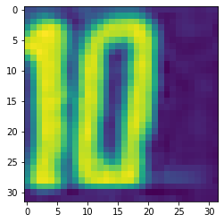

```
Label:  0
Actual Label - one hot encoded:  [1. 0. 0. 0. 0. 0. 0. 0. 0. 0.]
Predicted Label - one hot encoded:  [1 0 0 0 0 0 0 0 0 0]
```

```python
import matplotlib.pyplot as plt

X_val_temp=data['X_val'][:]
y_val_temp=data['y_val'][:]

plt.imshow(X_val_temp[0])    # show first number in the val dataset
plt.show()

print('Label: ', y_val_temp[0])
print('Actual Label - one hot encoded: ', y_val[0])
print('Predicted Label - one hot encoded: ', Y_pred_val_cls[0])
```

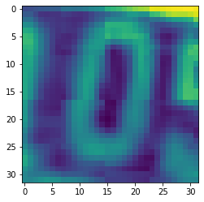

```
Label:  0
Actual Label - one hot encoded:   [1. 0. 0. 0. 0. 0. 0. 0. 0. 0.]
Predicted Label - one hot encoded:  [1 0 0 0 0 0 0 0 0 0]
```

```python
plt.imshow(X_val_temp[900])
plt.show()

print('Label: ', y_val_temp[900])
print('Actual Label - one hot encoded:  ', y_val[900])
print('Predicted Label - one hot encoded: ', Y_pred_val_cls[900])
```

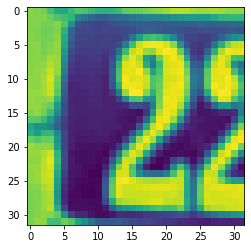

```
Label:  2
Actual Label - one hot encoded:  [0. 0. 1. 0. 0. 0. 0. 0. 0. 0.]
Predicted Label - one hot encoded:  [0 0 1 0 0 0 0 0 0 0]
```

```python
plt.imshow(X_val_temp[9500])
plt.show()

print('Label: ', y_val_temp[9500])
print('Actual Label - one hot encoded: ', y_val[9500])
print('Predicted Label - one hot encoded: ', Y_pred_val_cls[9500])
```